# Tema6-Tarea

Pep Matemales

29/3/2020

# Tarea T6

Instala y carga el paquete MASS. En el hay una tabla de datos llamada birthwt sobre factores que pueden incidir en el peso de los niños al nacer.

Preguntas de esta tarea 1. Utiliza str() y head() para explorar la estructura, y con help(), mirar el significado de cada variable. 2. Calcula una tabla de frecuencias relativas marginales de los pares (raza de la madre, peso inferior a 2.5 kg o no) que permita ver si la raza de la madre influye en el peso del bebé. 3. Dibuja un diagrama de mosaico de la tabla del ejercicio anterior. 4. Dibuja un diagrama bidimensional de barras, con las barras organizadas en bloques, que permita visualizar la información de los ejercicios anteriores. Aprovecha para nombres adecuados a los bloques, colores a las barras, y añadir una leyenda que explique qué representa cada barra. 5. ¿Se puede obtener alguna conclusión de la tabla y el diagrama de barras anterior? Argumenta tu respuesta 6. Repite los cuatro ejercicios anteriores para los pares (madre fumadora o no, peso inferior a 2.5 kg o no) y para los pares (madre hipertensa o no, peso inferior a 2.5 kg o no. 7. Calcula una tabla de frecuencias relativas marginales de las ternas (raza de la madre, madre fumadora o no, peso inferior a 2.5 kg o no) que permita ver si la raza de la madre y su condición de fumadora o no fumadora influyen en el peso del bebé. 8. Dibuja un diagrama de mosaico de la tabla del ejercicio anterior.

```r
library(MASS)
datostarea9=birthwt
```

1. Utiliza str() y head() para explorar la estructura, y con help(), mirar el significado de cada variable.

```r
str(datostarea9)
```

```
## 'data.frame':    189 obs. of  10 variables:
##  $ low  : int  0 0 0 0 0 0 0 0 0 0 ...
##  $ age  : int  19 33 20 21 18 21 22 17 29 26 ...
##  $ lwt  : int  182 155 105 108 107 124 118 103 123 113 ...
##  $ race : int  2 3 1 1 1 3 1 3 1 1 ...
##  $ smoke: int  0 0 1 1 1 0 0 0 1 1 ...
##  $ ptl  : int  0 0 0 0 0 0 0 0 0 0 ...
##  $ ht   : int  0 0 0 0 0 0 0 0 0 0 ...
##  $ ui   : int  1 0 0 1 1 0 0 0 0 0 ...
##  $ ftv  : int  0 3 1 2 0 0 1 1 1 0 ...
##  $ bwt  : int  2523 2551 2557 2594 2600 2622 2637 2637 2663 2665 ...
```

```r
head(datostarea9)
```

```
##    low age lwt race smoke ptl ht ui ftv  bwt
## 85   0  19 182    2     0   0  0  1   0 2523
## 86   0  33 155    3     0   0  0  0   3 2551
## 87   0  20 105    1     1   0  0  0   1 2557
## 88   0  21 108    1     1   0  0  1   2 2594
## 89   0  18 107    1     1   0  0  1   0 2600
## 91   0  21 124    3     0   0  0  0   0 2622
```

```r
datostarea9
```

[output not shown]

[output cut: 175 more lines]

Description: The birthwt data frame has 189 rows and 10 columns. The data were collected at Baystate Medical Center, Springfield, Mass during 1986.

Usage birthwt Format This data frame contains the following columns:

low indicator of birth weight less than 2.5 kg.

age mother’s age in years.

lwt mother’s weight in pounds at last menstrual period.

race mother’s race (1 = white, 2 = black, 3 = other).

smoke smoking status during pregnancy.

ptl number of previous premature labours.

ht history of hypertension.

ui presence of uterine irritability.

ftv number of physician visits during the first trimester.

bwt birth weight in grams.

2. Calcula una tabla de frecuencias relativas marginales de los pares (raza de la madre, peso inferior a 2.5 kg o no) que permita ver si la raza de la madre influye en el peso del bebé.

```r
Raza=datostarea9$race
Menos2.5=datostarea9$low
table(Raza,Menos2.5)
```

```
##     Menos2.5
## Raza  0  1
##    1 73 23
##    2 15 11
##    3 42 25
```

```r
tablaej2=table(Raza,Menos2.5)
dimnames(tablaej2)=list(
  Raza=c("Blanca","Negra","Otra"),
  Menosde2.5kg=c("No","Si")
)

tablaej2 #observemos la tabla de frec. abs.
```

```
##         Menosde2.5kg
## Raza     No Si
##   Blanca 73 23
##   Negra  15 11
##   Otra   42 25
```

```r
prop.table(tablaej2, margin = 2) #Esta tabla es poco util para ver si la raza de la madre influye en el peso ya que hace las relativas de cada raza dentro de los que pesan mas de 2.5 y dentro de los q pesan menos. Y claro puede haber menos negras dentro de los que pesan menos de 2.5 pero puede ser por el hecho de que haya menos negras en general.
```

```
##         Menosde2.5kg
## Raza            No        Si
##   Blanca 0.5615385 0.3898305
##   Negra  0.1153846 0.1864407
##   Otra   0.3230769 0.4237288
```

```r
prop.table(tablaej2, margin = 1) #Esta es mas util, pq nos separa las razas, y dentro de cada una muestra la probabilidad de que pese mas o menos 2.5.
```

```
##         Menosde2.5kg
## Raza            No        Si
##   Blanca 0.7604167 0.2395833
##   Negra  0.5769231 0.4230769
##   Otra   0.6268657 0.3731343
```

```r
#Observemos que de las blancas, un 76% tienen hijos que NO pesan menos de 2.5, ganando al 57% de las negras y 62% de otras.
#Y observemos que de las negras, un 42% tienen hijos q pesan menos de 2.5, ganando al 24% y 37% de las blancas y otras, respectivamente.
```

3. Dibuja un diagrama de mosaico de la tabla del ejercicio anterior.

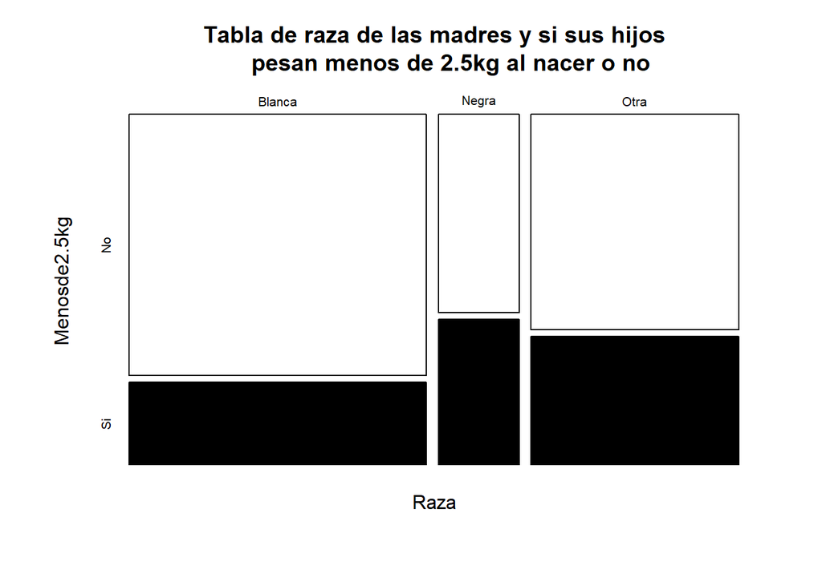

```r
plot(tablaej2, main="Tabla de raza de las madres y si sus hijos
     pesan menos de 2.5kg al nacer o no",
     col=c("white","black"),
     )
```

4. Dibuja un diagrama bidimensional de barras, con las barras organizadas en bloques, que permita visualizar la información de los ejercicios anteriores. Aprovecha para nombres adecuados a los bloques, colores a las barras, y añadir una leyenda que explique qué representa cada barra.

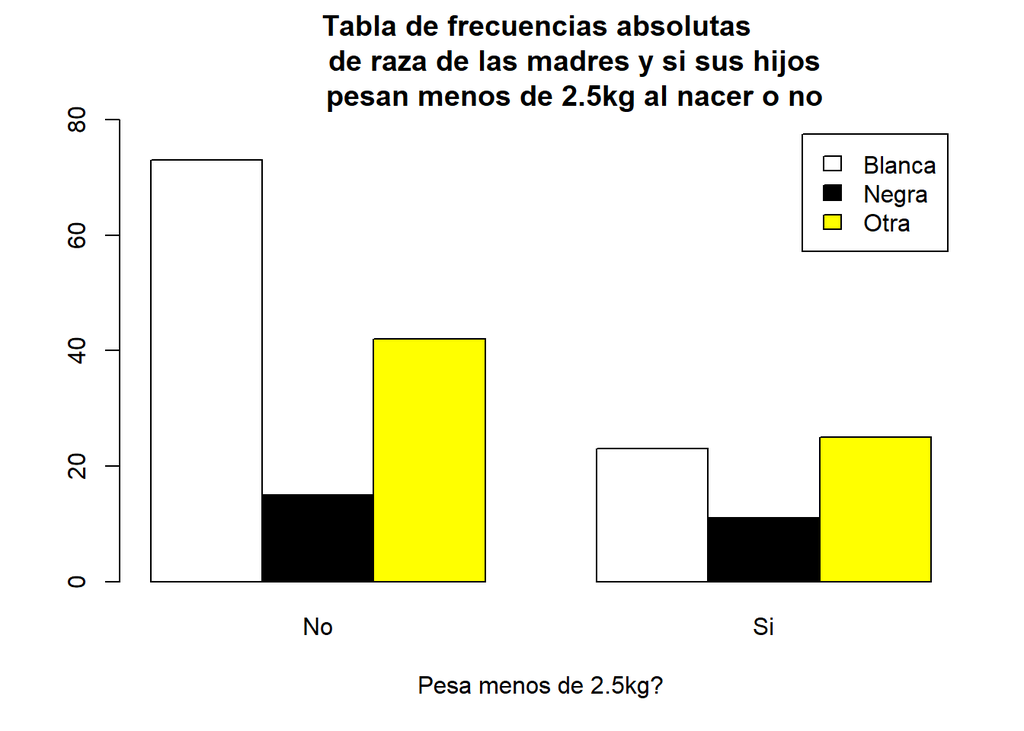

```r
#Grafico 1: Frecuencias absolutas de las razas de madres y si sus hijos pesan menos de 2.5. Observamos rapidamente en la  muestra, lo que mas hay son blancas con hijos que pesan MAS de 2.5kg.
barplot(tablaej2, beside=TRUE, legend.text = TRUE,
        col=c("white","black","yellow"),
        ylim = c(0,80), main="Tabla de frecuencias absolutas
        de raza de las madres y si sus hijos
        pesan menos de 2.5kg al nacer o no",
        xlab = "Pesa menos de 2.5kg?",
        )
```

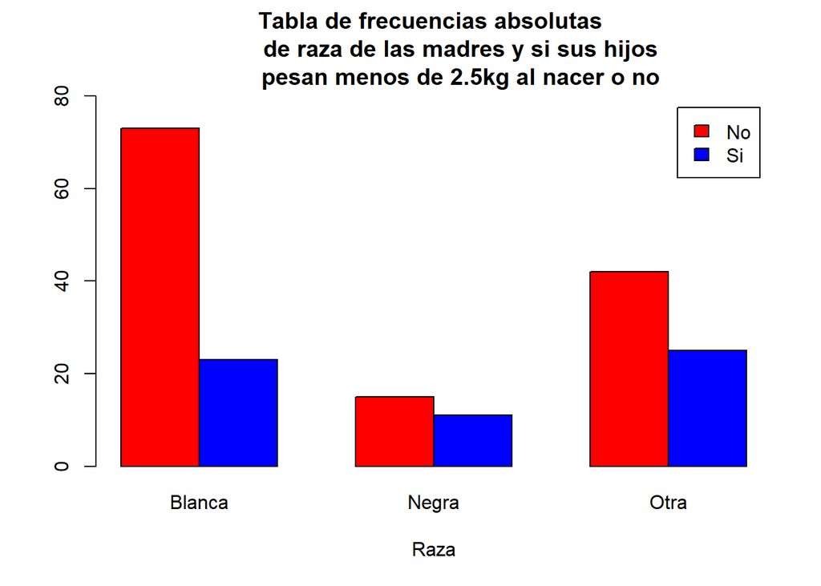

```r
#Grafico 2: Tambien es de frecuencias absolutas de las razas de madres y si sus hijos pesan menos de 2.5 pero hemos juntado blancas que si con blancas que no, negras que si con negras que no, y igual con otras. De esta forma vemos que dentro de las negras hay masomenos igual de las q tienen hijos de menos de 2.5 que de las de mas, al contrario que las blancas donde hay una gran diferencia entre si y no.
barplot(t(tablaej2), beside=TRUE, legend.text = TRUE,
        col=c("red","blue"),
        ylim = c(0,80), main="Tabla de frecuencias absolutas
        de raza de las madres y si sus hijos
        pesan menos de 2.5kg al nacer o no",
        xlab = "Raza",
        )
```

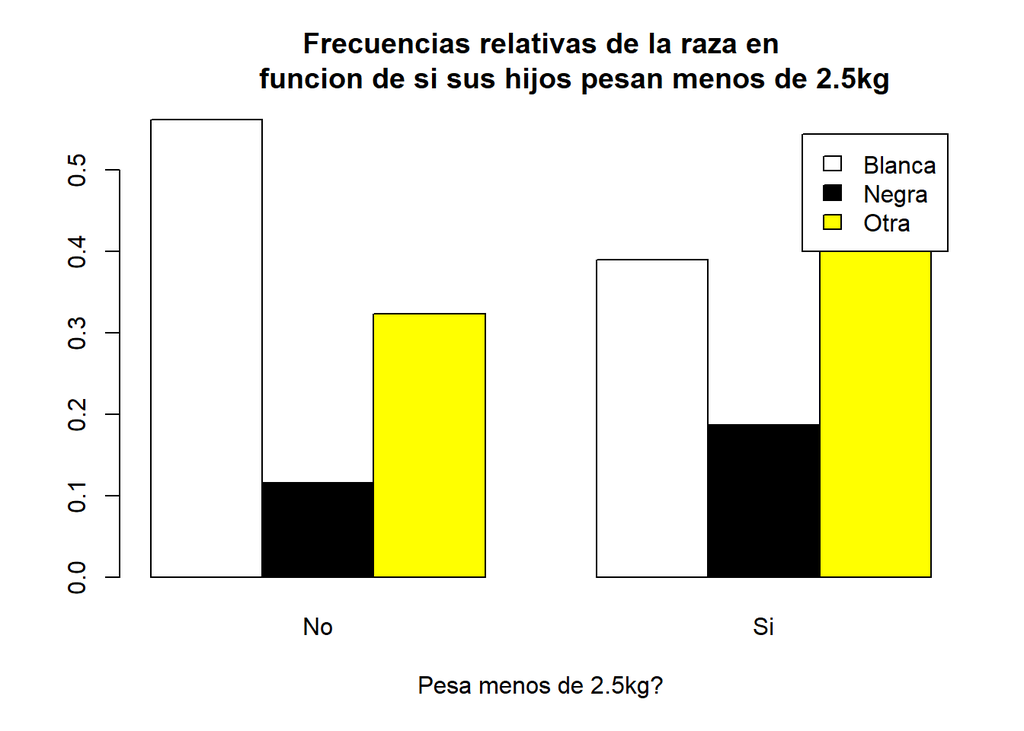

```r
#Grafico 3: Considero que es el grafico mas inutil ya que es el de las frecuencias relativas de la raza en funcion de si sus hijos pesan menos de 2.5kg. Es decir, mira dentro del si cuantas de cada raza hay y dentro del no cuantas de cada raza hay.
#Pero claro, puede ser que en la muestra haya pocas negras(y es lo que pasa) y puedas pensar que de las negras de todo el mundo muy pocas tengan hijos que pesen menos de 2.5kg, cosa que es erronea si vemos los proximos graficos.
barplot(prop.table(tablaej2, margin = 2), beside=TRUE, legend.text = TRUE,
        xlab = "Pesa menos de 2.5kg?", main="Frecuencias relativas de la raza en
        funcion de si sus hijos pesan menos de 2.5kg",
        col=c("white","black","yellow"),
        )
```

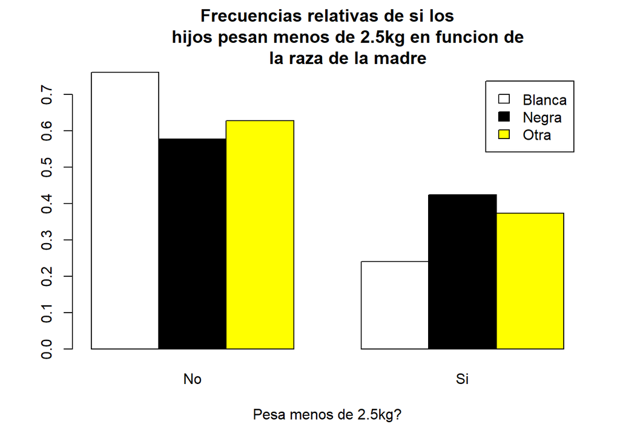

```r
#Graficos 4 y 5: Grafico de las frecuencias relativas de si los hijos pesan menos de 2.5kg en funcion de la raza de la madre.
#Observemos que de las negras, hay muchas que si tienen hijos con menos de 2.5kg, pero sin llegar a superar a las de mas. Pero de las blancas y de las otras, la diferencia entre mas y menos de 2.5 es mucho mas grande.
barplot(prop.table(tablaej2, margin = 1), beside=TRUE, legend.text = TRUE,
        xlab = "Pesa menos de 2.5kg?", main="Frecuencias relativas de si los
        hijos pesan menos de 2.5kg en funcion de
        la raza de la madre",
        col=c("white","black","yellow"),
        )
```

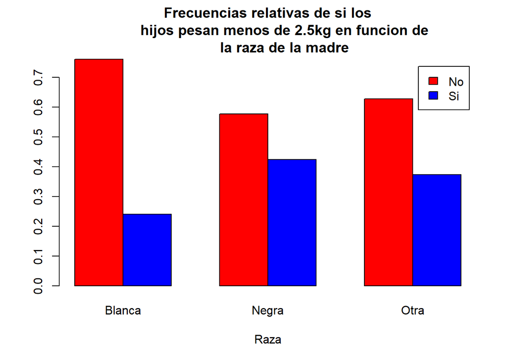

```r
barplot(t(prop.table(tablaej2, margin = 1)), beside=TRUE, legend.text = TRUE,
        xlab = "Raza", main="Frecuencias relativas de si los
        hijos pesan menos de 2.5kg en funcion de
        la raza de la madre",
        col=c("red","blue"),
        )
```

5. ¿Se puede obtener alguna conclusión de la tabla y el diagrama de barras anterior? Argumenta tu respuesta

Todo lo dicho en las observaciones anteriores, pero la conclusion es: Observemos que de las blancas, un 76% tienen hijos que NO pesan menos de 2.5, ganando al 57% de las negras y 62% de otras. Y observemos que de las negras, un 42% tienen hijos q pesan menos de 2.5, ganando al 24% y 37% de las blancas y otras, respectivamente.

7. Calcula una tabla de frecuencias relativas marginales de las ternas (raza de la madre, madre fumadora o no, peso inferior a 2.5 kg o no) que permita ver si la raza de la madre y su condición de fumadora o no fumadora influyen en el peso del bebé.

```r
Raza=factor(datostarea9$race, levels = c(1,2,3), labels=c("Blanca","Negra","Otra"))
Raza
```

```
##   [1] Negra  Otra   Blanca Blanca Blanca Otra   Blanca Otra   Blanca Blanca
##  [11] Otra   Otra   Otra   Otra   Blanca Blanca Negra  Blanca Otra   Blanca
##  [21] Otra   Blanca Blanca Otra   Otra   Blanca Blanca Blanca Negra  Negra
##  [31] Negra  Blanca Negra  Blanca Negra  Blanca Blanca Blanca Blanca Blanca
##  [41] Negra  Blanca Negra  Blanca Blanca Blanca Blanca Otra   Blanca Otra
##  [51] Blanca Otra   Blanca Blanca Otra   Otra   Otra   Otra   Otra   Otra
##  [61] Otra   Otra   Otra   Blanca Otra   Otra   Otra   Otra   Blanca Negra
##  [71] Blanca Otra   Otra   Negra  Blanca Negra  Blanca Blanca Negra  Blanca
##  [81] Blanca Blanca Otra   Otra   Otra   Otra   Otra   Blanca Blanca Blanca
##  [91] Blanca Otra   Blanca Blanca Blanca Blanca Blanca Blanca Blanca Blanca
## [101] Blanca Blanca Otra   Blanca Otra   Negra  Blanca Blanca Blanca Negra
## [111] Blanca Otra   Blanca Blanca Blanca Otra   Blanca Otra   Blanca Otra
## [121] Blanca Otra   Blanca Blanca Blanca Blanca Blanca Blanca Blanca Blanca
## [131] Otra   Blanca Negra  Otra   Otra   Otra   Otra   Negra  Otra   Blanca
## [141] Blanca Blanca Otra   Otra   Blanca Blanca Negra  Blanca Otra   Otra
## [151] Otra   Blanca Blanca Blanca Blanca Otra   Negra  Blanca Negra  Otra
## [161] Blanca Otra   Otra   Otra   Negra  Blanca Otra   Otra   Blanca Blanca
## [171] Negra  Negra  Negra  Otra   Otra   Blanca Blanca Blanca Blanca Negra
## [181] Otra   Otra   Blanca Otra   Blanca Otra   Otra   Negra  Blanca
## Levels: Blanca Negra Otra
```

```r
Fuma=factor(datostarea9$smoke, levels=c(0,1), labels=c("No","Si"))
Fuma
```

```
##   [1] No No Si Si Si No No No Si Si No No No No Si Si No Si No Si No No No No No
##  [26] No Si No Si No No Si Si No No Si Si Si Si Si Si No No No Si Si No No No Si
##  [51] No No Si Si No No Si No No No No No No No Si No No Si No No Si Si Si No Si
##  [76] No No Si Si No No No No No No Si No No No No No No Si Si Si No No Si Si No
## [101] No Si No No No No No No Si No No No Si No Si No No No No No No No No No No
## [126] No No Si No No Si No Si No No No No No No Si Si Si No No Si Si No Si No No
## [151] No No Si Si No Si Si Si No Si Si No No No Si Si No No Si No Si Si Si No No
## [176] Si Si Si Si No No No Si Si Si No Si No Si
## Levels: No Si
```

```r
Menos2.5=factor(datostarea9$low, levels=c(0,1), labels=c("No","Si"))
Menos2.5
```

```
##   [1] No No No No No No No No No No No No No No No No No No No No No No No No No
##  [26] No No No No No No No No No No No No No No No No No No No No No No No No No
##  [51] No No No No No No No No No No No No No No No No No No No No No No No No No
##  [76] No No No No No No No No No No No No No No No No No No No No No No No No No
## [101] No No No No No No No No No No No No No No No No No No No No No No No No No
## [126] No No No No No Si Si Si Si Si Si Si Si Si Si Si Si Si Si Si Si Si Si Si Si
## [151] Si Si Si Si Si Si Si Si Si Si Si Si Si Si Si Si Si Si Si Si Si Si Si Si Si
## [176] Si Si Si Si Si Si Si Si Si Si Si Si Si Si
## Levels: No Si
```

```r
tablaej7=table(Menos2.5,Fuma,Raza)
dimnames(tablaej7)
```

```
## $Menos2.5
## [1] "No" "Si"
##
## $Fuma
## [1] "No" "Si"
##
## $Raza
## [1] "Blanca" "Negra"  "Otra"
```